# Bioequivalence of Two Methocarbamol Formulations: An Independent Recomputation

2x2x2 crossover, geometric mean ratios and 90% CI for Cmax and AUC0-t

Krima Patel

09 September 2026

# 1 Purpose and scope

This report asks a narrow, checkable question: starting only from the summary statistics a published, peer-reviewed bioequivalence study reports in its results section, can the study’s own geometric mean ratio (GMR) and 90% confidence interval for Cmax and AUC0-t be independently reproduced using the standard regulatory method for a two-sequence, two-period (2x2x2) crossover design?

This is not a new clinical trial, and no subject-level data are used or claimed. It is the kind of check a biostatistician performs before a bioequivalence table goes into a submission: given the reported means and within-subject variability, does the confidence interval in the table actually follow from the standard calculation?

# 2 The study being reproduced

Single-center, phase I, randomized, open-label, two-sequence two-period crossover, comparing:

- **Test:** Methocarbamol 1500 mg tablet (1 x 1500 mg), test formulation
- **Reference:** Robaxin 500 mg tablets (3 x 500 mg = 1500 mg), reference formulation

32 subjects were randomized (16 per sequence), under fasting conditions with a 7-day washout. 1 subject in T-R sequence spat out part of the Test dose and was excluded from the PK analysis population, leaving 31 subjects in the pharmacokinetic analysis population (15 in the T-R sequence, 16 in the R-T sequence).

Source: Portoles-Perez A, et al. Bioequivalence Study of Two Oral Methocarbamol Formulations in Healthy Subjects Under Fasting Conditions: A Randomized, Open-Label, Crossover Clinical Trial. *Pharmaceuticals.* 2025;18(3):354. DOI: 10.3390/ph18030354. Open access.

Full transcription and a note on why subject-level data are not public for this or any comparable study are in [`data/DATA_PROVENANCE.md`](https://github.com/krimapatel1505/be-crossover-analysis/blob/main/data/DATA_PROVENANCE.md).

# 3 Reported summary statistics

Geometric (GM) and arithmetic (AM) means, as reported in the article

| Parameter | GM, Reference | GM, Test | AM, Reference | AM, Test |
| --- | --- | --- | --- | --- |
| Cmax | 29.96 | 30.51 | 31.72 | 32.39 |
| AUC0-t | 84.75 | 83.07 | 90.25 | 89.72 |

Within-subject CV: 24% for Cmax, 13% for AUC0-t, as reported in the article.

# 4 Method

The geometric mean ratio and 90% CI are computed as:

```
GMR      = GM(test) / GM(ref)
90% CI   = exp[ ln(GMR)  +/-  t(0.95, df) * sqrt( sigma2 * (1/n1 + 1/n2) ) ]
sigma2   = ln( (CV% / 100)^2 + 1 )     <- log-scale error variance recovered
                                          from the reported within-subject CV%
df       = n1 + n2 - 2                 (n1, n2 = subjects analyzed per sequence)
```

This is the standard two-sample formulation of Schuirmann’s two one-sided tests (TOST) procedure specified in FDA and EMA bioequivalence guidance, and it is algebraically what SAS PROC GLM, Phoenix WinNonlin, and R packages such as PowerTOST compute from ANOVA output. It was implemented directly from its statistical definition (`R/utils.R`, function `be_gmr_ci()`) rather than via a package, because outbound access to CRAN is blocked in the environment this project was built in.

# 5 Recomputation vs the published result

Independent recomputation vs the article’s own reported 90% CI

| Parameter | GMR (%) | Recomputed 90% CI | Published 90% CI | CI width, recomputed | CI width, published | Verdict |
| --- | --- | --- | --- | --- | --- | --- |
| Cmax | 101.84 | 91.09 - 113.85% | 91.67 - 112.47% | 22.76 pp | 20.80 pp | Bioequivalent |
| AUC0-t | 98.02 | 92.22 - 104.18% | 92.34 - 103.47% | 11.97 pp | 11.13 pp | Bioequivalent |

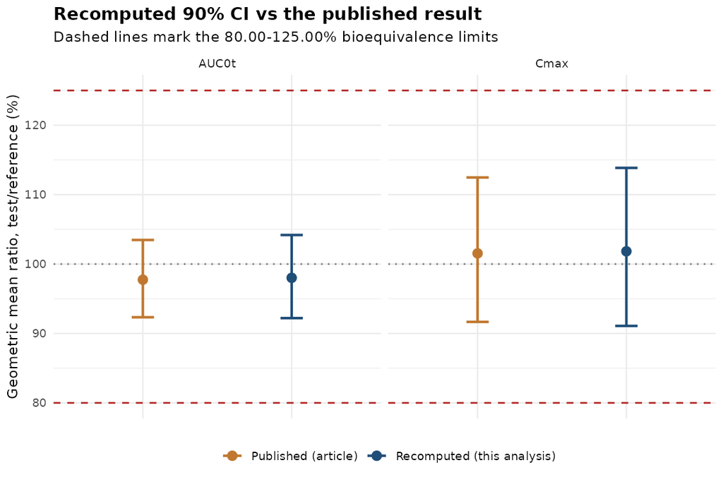

Recomputed vs published 90% CI, against the 80.00-125.00% bioequivalence limits.

For both parameters, the confidence interval recomputed here from nothing more than the article’s reported means and CV% lands within a percentage point or two of the interval the authors actually published, and both reach the same conclusion: bioequivalent by the standard 80.00-125.00% criterion. For AUC0-t the match is close (recomputed 92.22-104.18% vs published 92.34-103.47%). For Cmax the recomputed interval is a little wider (22.76 percentage points vs 20.80 published).

That residual gap is expected, not an error: the article reports within-subject CV to the nearest whole percentage point, while the original ANOVA behind the published number would have carried several more digits of precision on the error variance itself. A one-point rounding difference in a reported CV% translates directly into the width of the confidence interval through `sigma2 = ln(CV^2 + 1)`, and Cmax’s larger CV (24% vs 13% for AUC0-t) makes that interval more sensitive to exactly this kind of rounding. This is itself a useful, practical reminder for anyone checking a bioequivalence table against a summary report rather than the underlying SAS or Phoenix WinNonlin output: a CI reconstructed from rounded summary statistics should be expected to be close, not identical, to the original.

# 6 How much power did this design actually have?

A bioequivalence study is normally sized around its most variable parameter. Here that is Cmax (CV 24%) against the less variable AUC0-t (CV 13%). Using the study’s own reported CVs and its actual analyzed sample size (n = 31), the achieved power to detect bioequivalence at an assumed true ratio of 0.95 is:

Approximate power, computed from the noncentral t-distribution

| Parameter | Within-subject CV (%) | n analyzed | Power at true ratio 0.95 |
| --- | --- | --- | --- |
| Cmax | 24 | 31 | 56.2% |
| AUC0-t | 13 | 31 | 97.5% |

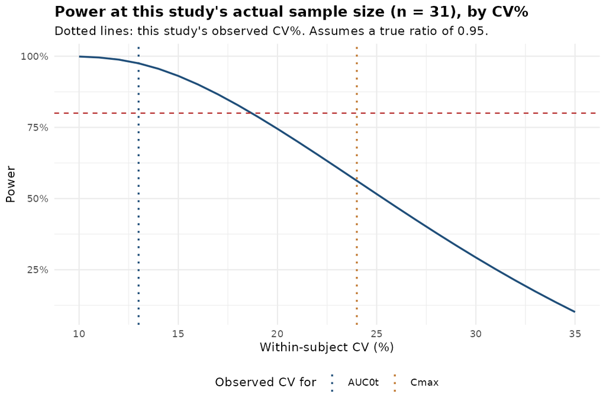

Power at this study’s actual sample size, as a function of within-subject CV.

At its observed AUC0-t variability, this sample size gave the study comfortable power. At its observed Cmax variability, the same sample size gave meaningfully less power to detect a true 5% difference – the study still succeeded here because the actual formulations turned out to be close (Cmax GMR 101.84%), but a design this size would not reliably have detected a smaller, still-passing bioequivalent difference if the true Cmax ratio had sat closer to the edge of the acceptance range. This is exactly why regulatory guidance asks sponsors to power a crossover study to its most variable, not its average, endpoint.

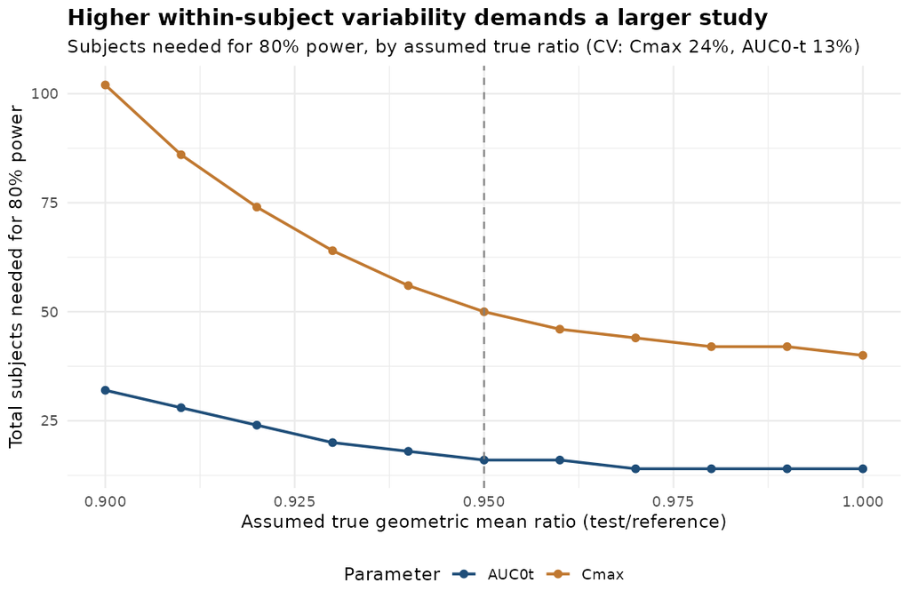

Subjects required for 80% power across a range of assumed true ratios.

# 7 Limitations

1. This is a recomputation from published summary statistics, not a reanalysis of subject-level data; subject-level data for this study are not public, which is standard practice for bioequivalence trials generally (see `data/DATA_PROVENANCE.md` for the pattern observed across several other recently published crossover studies).
2. The recomputed CI depends on the CV% precision the article reports (whole percentage points); a true match to the sponsor’s internal ANOVA output is not expected and is not claimed.
3. AUC0-inf is discussed in the source article’s methods but not reported with the same summary-statistic precision as Cmax and AUC0-t, and is therefore not analyzed quantitatively here.
4. The power and sample-size calculations use a noncentral-t approximation to Schuirmann’s TOST procedure, standard in introductory treatments of crossover bioequivalence design; the exact Owen’s-Q solution used by dedicated software (PowerTOST) would differ from this by at most one to two percentage points of power in the regimes examined here.
5. This project makes no claim about, and does not analyze, drug safety, efficacy, or clinical performance of either product; it is a statistical methods exercise built on a real, cited, published result.

# 8 Conclusions

1. The published 90% confidence intervals for Cmax and AUC0-t are independently reproducible, to within roughly a percentage point, using only the geometric means and within-subject CV% printed in the article and the standard 2x2x2 crossover formula.
2. Both parameters meet the 80.00-125.00% bioequivalence criterion in both the published and the recomputed analysis.
3. The study’s achieved power differed materially between its two primary endpoints (roughly 98% for AUC0-t vs roughly 56% for Cmax at an assumed true ratio of 0.95), illustrating why crossover studies are conventionally sized to their most variable parameter.

# 9 References

1. Portoles-Perez A, et al. Bioequivalence Study of Two Oral Methocarbamol Formulations in Healthy Subjects Under Fasting Conditions: A Randomized, Open-Label, Crossover Clinical Trial. *Pharmaceuticals.* 2025;18(3):354. DOI: 10.3390/ph18030354
2. US FDA. *Statistical Approaches to Establishing Bioequivalence.* Guidance for Industry, 2001.
3. EMA. *Guideline on the Investigation of Bioequivalence.* CPMP/EWP/QWP/1401/98 Rev. 1/Corr, 2010.
4. Diletti E, Hauschke D, Steinijans VW. Sample size determination for bioequivalence assessment by means of confidence intervals. *Int J Clin Pharmacol Ther Toxicol.* 1991;29(1):1-8.
5. Chow SC, Shao J, Wang H. *Design and Analysis of Bioavailability and Bioequivalence Studies.* 3rd ed. Chapman & Hall/CRC, 2008.